# ETC3250/5250 Assignment 2

SOLUTION

## Marks

- Total mark will be out or 25
- 3 points will be reserved for readability, and appropriate citing of external sources
- 2 points will be reserved for reproducibility, that the report can be re-generated from the submitted Rmarkdown.
- Accuracy and completeness of answers, and clarity of explanations will be the basis for the remaining 20 points.

## Exercises

1. (5pts)This question is about the normal distribution, and how it relates to the classification rule provided by quadratic discriminant analysis.
   1. Write down the density function for a univariate normal distribution ($p=1$), with mean $\mu_k$ and variance $\sigma_k$.
      $$f_k(x) = \frac{1}{\sqrt{2 \pi} \sigma_k} \text{exp}~ \left\{ - \frac{1}{2 } \left(\frac{x - \mu_k}{\sigma_k}\right)^2 \right\}$$
   2. Show that the quadratic discriminant rule for two groups ($K=2$), $\pi_1=\pi_2$ is equal to: *Assign a new observation $x_0$ to group 1 if*
      $$-\frac12 \left( \frac{1}{\sigma_1^2}- \frac{1}{\sigma_2^2} \right) {x_0^2} + \left(\frac{\mu_1}{\sigma_1^2}-\frac{\mu_2}{\sigma_2^2}\right)x_0 -\frac12 \left(\frac{\mu_1^2}{\sigma_1^2}- \frac{\mu_2^2}{\sigma_2^2} \right) + -\log{\sigma_1}+\log{\sigma_2}>0$$
      *For* $\mu_1, \mu_2, \sigma_1, \sigma_2$ *and assume* $\pi_1=\pi_2$,
      $$\begin{align*}
      &p_1(x_0) > p_2(x_0)\\
      &\Rightarrow \frac{1}{\sqrt{2\pi}\sigma_1} \text{exp} \left\{ - \frac{1}{2 } \left(\frac{x_0 - \mu_1}{\sigma_1}\right)^2 \right\} > \frac{1}{\sqrt{2\pi}\sigma_2} \text{exp} \left\{ - \frac{1}{2 } \left(\frac{x_0 - \mu_2}{\sigma_2}\right)^2 \right\}\\
      &\Rightarrow -\log \sigma_1 -\frac12\left(\frac{x_0-\mu_1}{\sigma_1}\right)^2 > -\log \sigma_2 -\frac12\left(\frac{x_0-\mu_2}{\sigma_2}\right)^2\\
      &\Rightarrow -\log \sigma_1 -\frac{1}{2\sigma_1^2}\left(x_0^2-2\mu_1x_0+\mu_1^2\right) > -\log \sigma_2 -\frac{1}{2\sigma_2^2}\left(x_0^2-2\mu_2x_0+\mu_2^2\right) \\
      &\Rightarrow -\frac12 \left( \frac{1}{\sigma_1^2}- \frac{1}{\sigma_2^2} \right) {x_0^2} + \left(\frac{\mu_1}{\sigma_1^2}-\frac{\mu_2}{\sigma_2^2}\right)x_0 -\frac12 \left(\frac{\mu_1^2}{\sigma_1^2}- \frac{\mu_2^2}{\sigma_2^2} \right) - \log{\sigma_1}+\log{\sigma_2}> 0
      \end{align*}$$
   3. Suppose $\mu_1=4, \mu_2=-5, \sigma_1=0.5, \sigma_2=5$ simulate a set of 50 observations from each population. Make a plot of the population model, and add these samples as a rug plot on the horizontal axis. (See the lecture notes for a similar plot and code for linear discriminant analysis.)

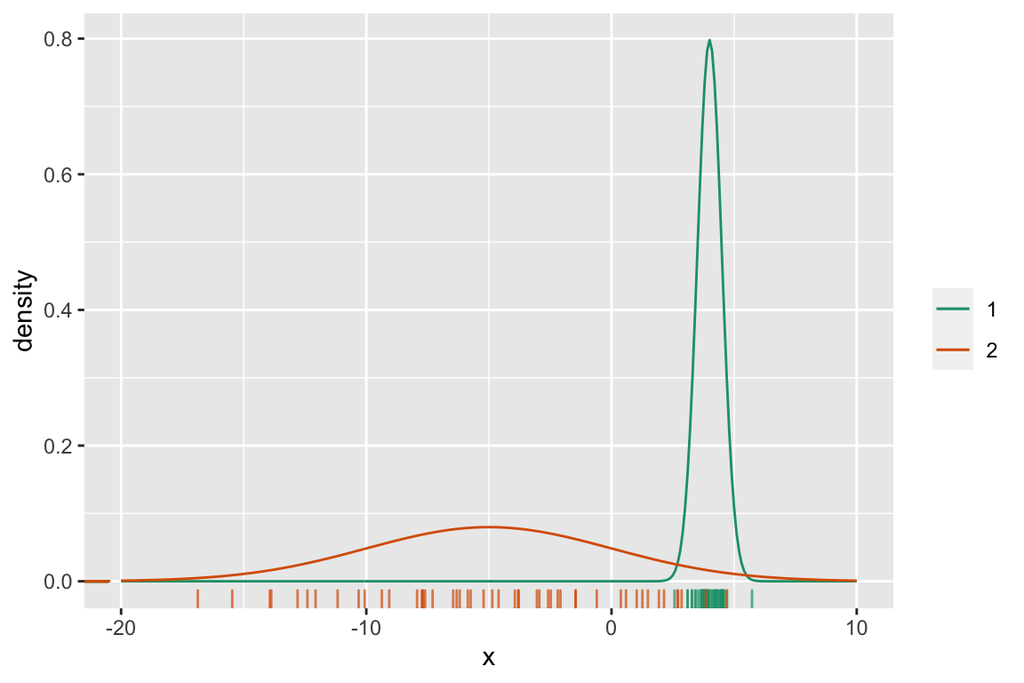

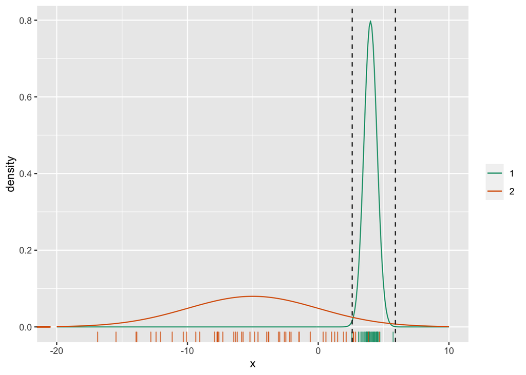

e. If instead you had made a mistake and assumed that the two variances were equal, this would have produced a linear discrimant rule. Mark this boundary on the previous plot. Explain why and how this differs from result of the QDA rule. *The boundary wuold be the average of the two means, that is -0.5. This doesn’t provide a good boundary, because it doesn’t take into account that group 1 has a much smaller variance than group 2. A lot of gruop 2 observations would be misclassified with the LDA rule.*

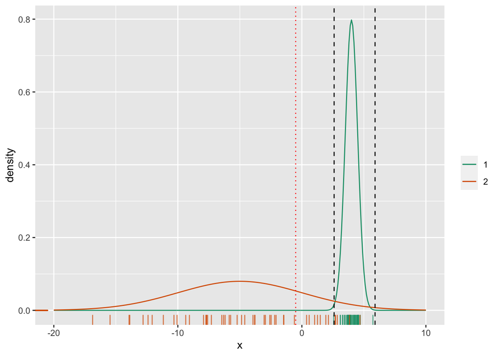

2. (4pts)In this question you are going to practice conducting bootstrap to obtain confidence intervals for a reasonably complicated yet simple analysis.

*A significant gender gap in maths performance in favour of male students has returned, despite closing in 2015* [Natassia Chrysanthos, Sydney Morning Herald](https://www.smh.com.au/national/nsw/urgent-need-to-address-maths-performance-as-nsw-slumps-in-international-test-20191203-p53ge2.html)

Last December, the 2018 [OECD PISA results](http://www.oecd.org/pisa/data/) were released. These are standardised test scores in math, reading and science, of 15 year olds across the globe. It led to a flurry of articles in the news about slipping standards of Australian students. If you also browsed the news of other countries (including New Zealand, Indonesia, Finland), you would find that many had similarly woeful stories. The above headline focuses on the math gap. To explore this, we will compute bootstrap confidence intervals for the difference between weighted averages for boys and girls in each country. The data is from the 2015 results.

The code block below will compute the difference between weighted averages for boys and girls in each country. A weighted average is often used with survey data, to reflect how the sampling was done relative to the population characteristics. The weighted average will typically better reflect the population mean.

This block of code will compute 90% bootstrap confidence intervals for the weighted mean difference.

This block of code will add country names, and make dotplots with confidence intervals for the math gap for each country.

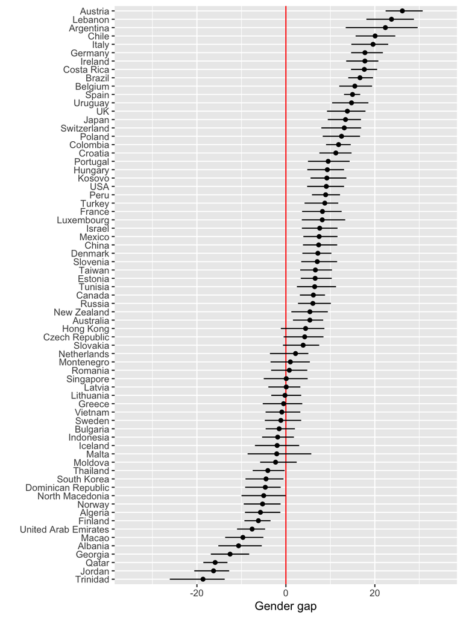

Write a paragraph explaining what you learn about the math gap across the countries tested in 2015.

*The gender gap for math is not universal. In a little more than half of the countries surveyed boys have a higher average math score than girls. In some countries girls scored higher on average than boys in math, and many countries have no significant difference between the averages.*

*Over the 5 month period the Australian dollar has weakened against the US dollar, with a big decline in mid-March as the coronavirus impact affected the world.*

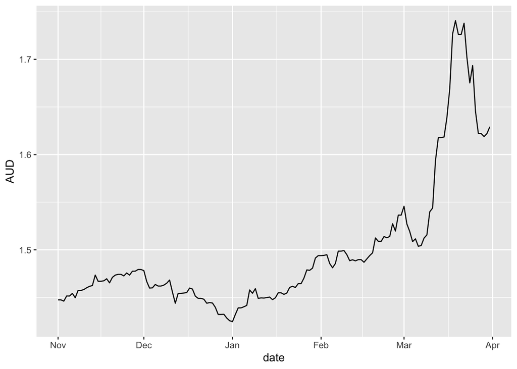

2. (1)You are going to work with these currencies: AUD, CAD, CHF, CNY, EUR, GBP, INR, JPY, KRW, MXN, NZD, RUB, SEK, SGD, ZAR. List the names of the countries and currency name that these codes refer to. Secondary question: why is the USD a constant 1 in this data.

*The US is the base rate, against which all other currencies are compared.*

3. (2)The goal of the principal component analysis is to examine the relative movement of this subset of currencies, especially since coronavirus emerged until the end of March. PCA is used to summarise the volatility (variance) in the currencies, relative to each other. To do this you need to:
   - Standardise all the currencies, individually. The resulting values will have a mean 0 and standard deviation equal to 1.
   - Flip the sigm so that high means the currency strengthened against the USD, and low means that it weakened. Its easier to explain trends, if you don’t need to talk with double-negatives.
   - Make a plot of all the currencies to check the result.

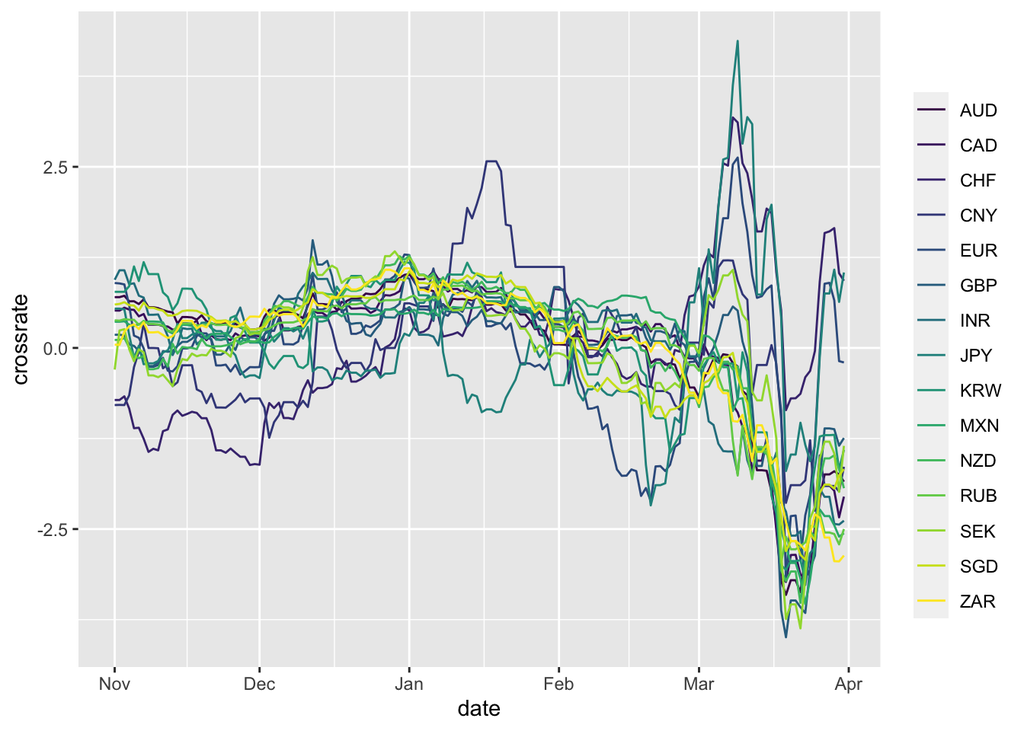

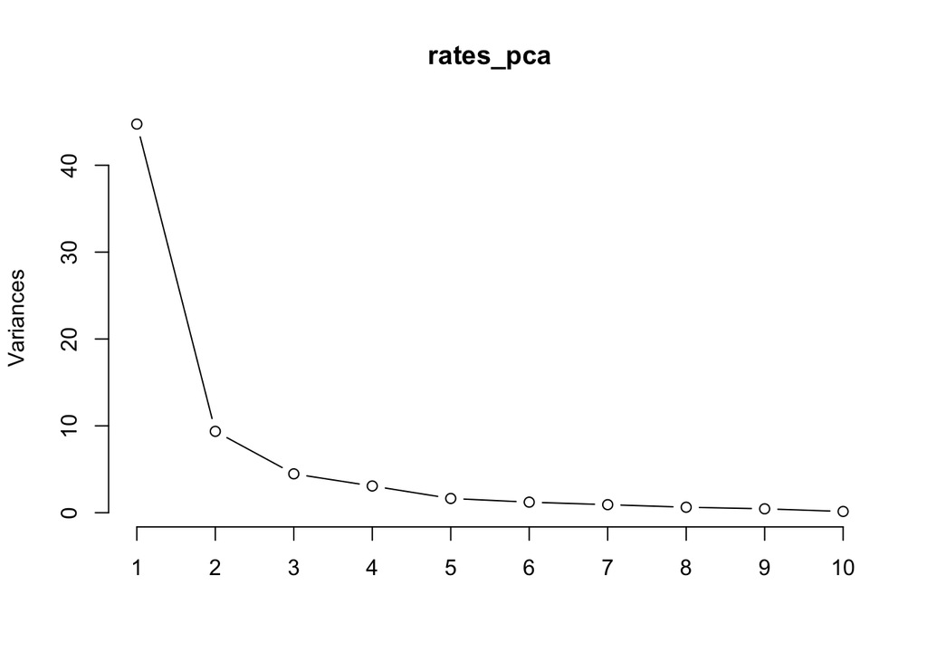

```
## Importance of components:
##                           PC1    PC2     PC3     PC4     PC5     PC6     PC7
## Standard deviation     6.6889 3.0604 2.11501 1.75429 1.28077 1.10197 0.96250
## Proportion of Variance 0.6674 0.1397 0.06673 0.04591 0.02447 0.01811 0.01382
## Cumulative Proportion  0.6674 0.8071 0.87387 0.91978 0.94425 0.96236 0.97618
##                            PC8     PC9    PC10    PC11    PC12    PC13    PC14
## Standard deviation     0.79487 0.66991 0.37970 0.36507 0.30562 0.28223 0.25608
## Proportion of Variance 0.00942 0.00669 0.00215 0.00199 0.00139 0.00119 0.00098
## Cumulative Proportion  0.98561 0.99230 0.99445 0.99644 0.99783 0.99902 1.00000
##                             PC15
## Standard deviation     9.126e-16
## Proportion of Variance 0.000e+00
## Cumulative Proportion  1.000e+00
```

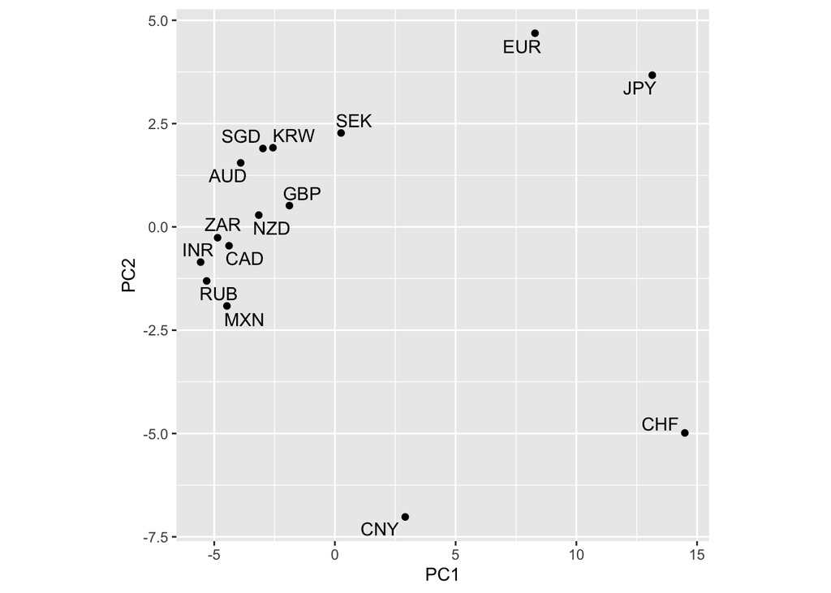

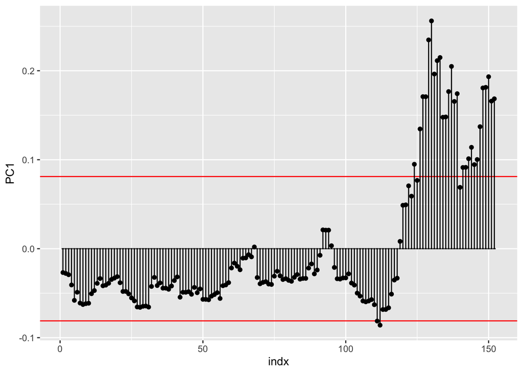

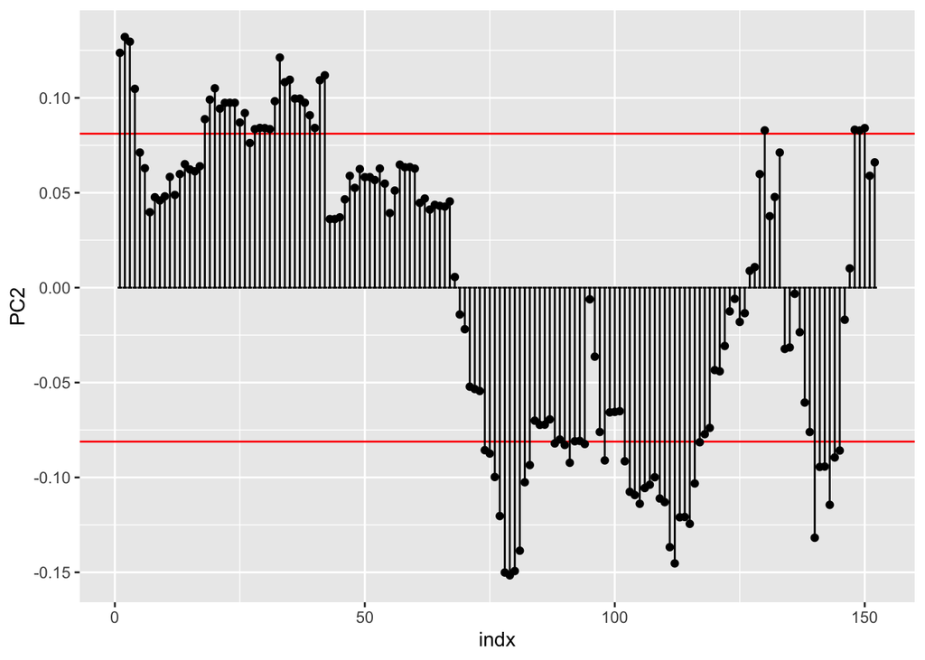

4. (2pts)What’s wrong with the following statement?

**Principle component analysis is a dimension reduction technique**.

*Principle has an entirely different meaning than principal. The latter means first or major, and the former means a convention or belief. The correct statement is: “Principal component analysis is a dimension reduction technqiue.”*